# IODS course project

# Excercise 5

## 1) Graphical overview and summary of the data

```r
install.packages("ggplot2", repos="http://cran.us.r-project.org")
install.packages("GGally", repos="http://cran.us.r-project.org")
install.packages("dplyr", repos="http://cran.us.r-project.org")
install.packages("corrplot", repos="http://cran.us.r-project.org")
install.packages("MASS", repos="http://cran.us.r-project.org")
install.packages("stringr", repos="http://cran.us.r-project.org")
library(ggplot2)
library(GGally)
library(dplyr)
library(corrplot)
library(MASS)
library(stringr)

install.packages("tidyr", repos="http://cran.us.r-project.org")
library(tidyr)

url <- "/Users/ville/Documents/IODS-project/data/human_"


human <- read.table(url, header=TRUE)
str(human)
```

```
## 'data.frame':    155 obs. of  8 variables:
##  $ edu_ratio          : num  1.007 0.997 0.983 0.989 0.969 ...
##  $ participation_ratio: num  0.891 0.819 0.825 0.884 0.829 ...
##  $ life_expect        : num  81.6 82.4 83 80.2 81.6 80.9 80.9 79.1 82 81.8 ...
##  $ yeducation         : num  17.5 20.2 15.8 18.7 17.9 16.5 18.6 16.5 15.9 19.2 ...
##  $ GNI                : Factor w/ 155 levels "1,123","1,228",..: 132 109 124 112 113 111 103 123 108 93 ...
##  $ M_Mortality        : int  4 6 6 5 6 7 9 28 11 8 ...
##  $ B_rate             : num  7.8 12.1 1.9 5.1 6.2 3.8 8.2 31 14.5 25.3 ...
##  $ Parliament         : num  39.6 30.5 28.5 38 36.9 36.9 19.9 19.4 28.2 31.4 ...
```

```r
human$GNI <- str_replace(human$GNI, pattern=",", replace ="") %>% as.numeric()

str(human$GNI)
```

```
##  num [1:155] 64992 42261 56431 44025 45435 ...
```

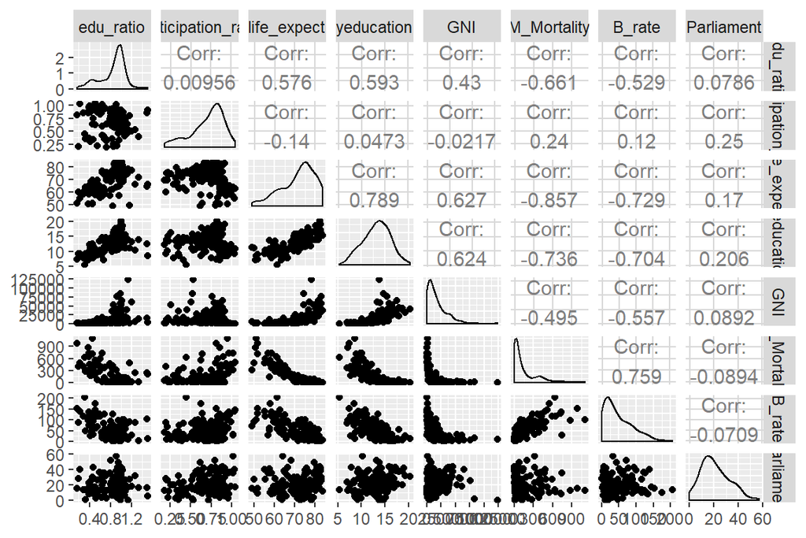

```r
ggpairs(human)
```

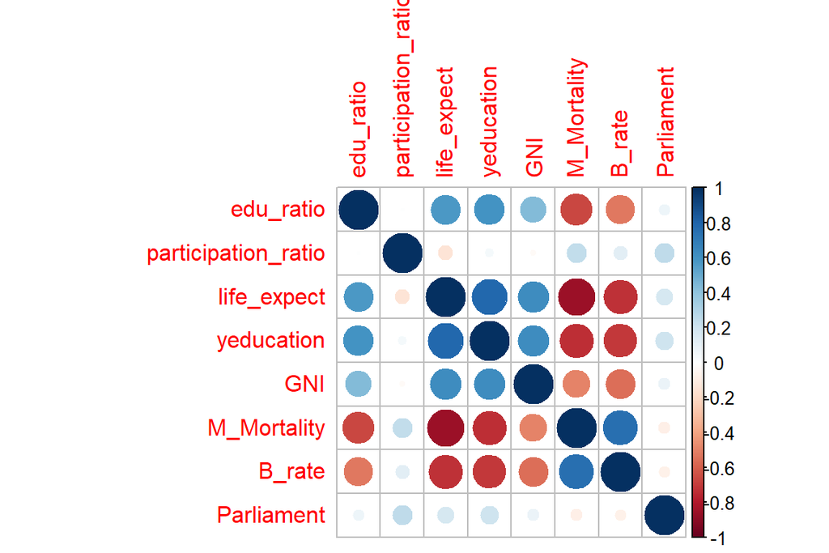

```r
cor(human) %>% corrplot()
```

From the above corrplot picture we can see the correlations between the variables. There seems to be strong positive correlation between Average years of education and life expectancy at birth. Also theres a negative correlation between maternal mortality and average years of education. GNI also has positive correlation with life expectancy and average years of education and negative correlation with maternal mortality rate and birth rate.

## 2) PCA analysis on not standardized data

```r
pca_human <- prcomp(human)

s <- summary(pca_human)
s
```

```
## Importance of components:
##                              PC1      PC2   PC3   PC4   PC5   PC6    PC7
## Standard deviation     1.854e+04 185.5219 25.19 11.45 3.766 1.566 0.1912
## Proportion of Variance 9.999e-01   0.0001  0.00  0.00 0.000 0.000 0.0000
## Cumulative Proportion  9.999e-01   1.0000  1.00  1.00 1.000 1.000 1.0000
##                           PC8
## Standard deviation     0.1591
## Proportion of Variance 0.0000
## Cumulative Proportion  1.0000
```

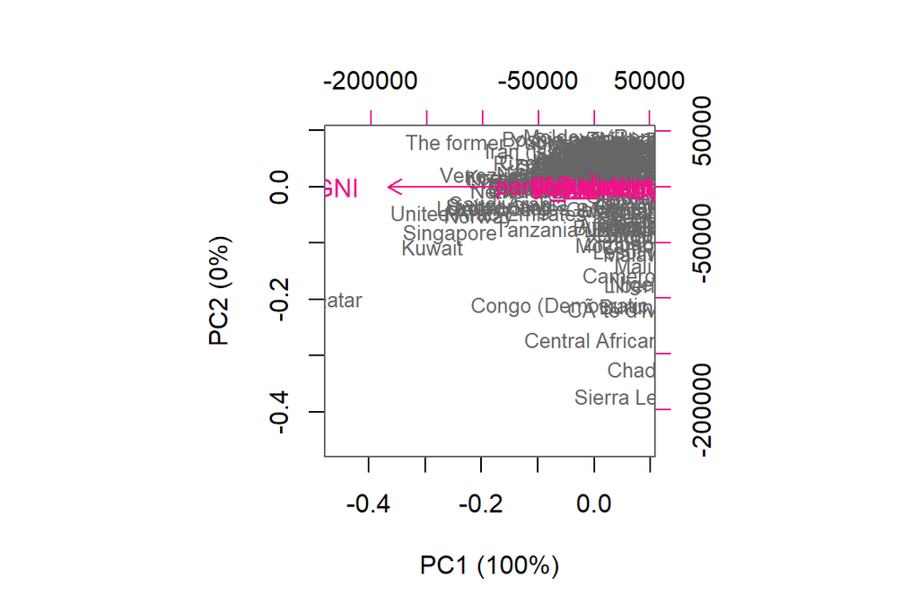

```r
pca_pr <- round(100*s$importance[2, ], digits = 1)
pc_lab <- paste0(names(pca_pr), " (", pca_pr, "%)")

biplot(pca_human, cex = c(0.8, 1), col = c("grey40", "deeppink2"), xlab = pc_lab[1], ylab = pc_lab[2])
```

From the unstandardized PCA we can see that the Principal components cannot be separated as all the components are in PC1 and it explains the variance completely.

## 3 PCA with standardized variables

```r
human_std <- scale(human)
pca_human_std <- prcomp(human_std)

s2 <- summary(pca_human_std)
s2
```

```
## Importance of components:
##                           PC1    PC2     PC3     PC4     PC5     PC6
## Standard deviation     2.0708 1.1397 0.87505 0.77886 0.66196 0.53631
## Proportion of Variance 0.5361 0.1624 0.09571 0.07583 0.05477 0.03595
## Cumulative Proportion  0.5361 0.6984 0.79413 0.86996 0.92473 0.96069
##                            PC7     PC8
## Standard deviation     0.45900 0.32224
## Proportion of Variance 0.02634 0.01298
## Cumulative Proportion  0.98702 1.00000
```

```r
pca_pr <- round(100*s2$importance[2, ], digits = 1)

pca_pr
```

```
##  PC1  PC2  PC3  PC4  PC5  PC6  PC7  PC8
## 53.6 16.2  9.6  7.6  5.5  3.6  2.6  1.3
```

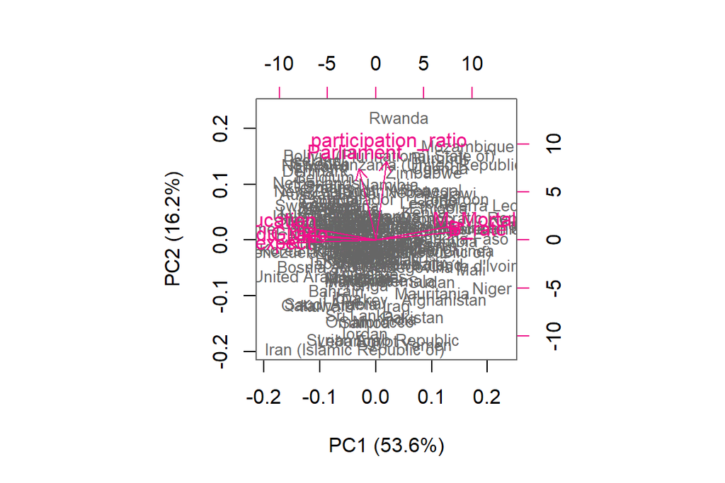

```r
pc_lab <- paste0(names(pca_pr), " (", pca_pr, "%)")

biplot(pca_human_std, cex = c(0.8, 1), col = c("grey40", "deeppink2"), xlab = pc_lab[1], ylab = pc_lab[2])
```